```python
# Run this cell first!
import pandas as pd
import numpy as np
%matplotlib inline
import matplotlib.pyplot as plt
import seaborn as sns
```

# Modelling Yearly Average PEPM Costs For Huntington Hospital

The ultimate goal of this project is to build a model to predict the total cost of Huntington Hospital's self-insured health plan using the prior 36 months of data. More specifically, this model will be created to use the observed monthly PEPM costs to predict the average yearly PEPM cost for the following year to aid in the renewal process.

## Background

For any underwriting team calculating renewal rates can be a frustratingly difficult process. The main concern posed to underwriters is the volatility of claims experience data. Year-by-year and even month-by-month breakdowns of claims experience data yield often inconsistent numbers with frustratingly high variance. An experienced underwriter will take their industry knowledge and apply it to historical claims experience data to mitigate the impact of volatility on their renewal projections. This project aims to leverage Machine Learning models to aid the underwriter in the renewal projection process. As an aside, there is often a misconception surrounding Data Science that the point of creating Machine Learning models is to completely strip away the human element; however the model is merely performing a series of Linear Algebra calculations that must be made sense of within the greater context of the insurance space. Moreover, it is alongside expert feedback/insight that the model was created--it is inherently human as much as it is automated. In light of that, I want to thank both Kyle for providing that expert insight throughout the process and the entire BUAD team for helping me learn more about employer-sponsored health plans and the ins-and-outs of the space--without all of you this project could not have come togeether.

### Basic Methodology

Since our goal is to predict annual renewal rate increases, the granularity of the data will be yearly (i.e. each row will represent a **Renewal Year** and not a standard year). However, because Huntington Medical Group has data going back only to 2015, this doesn't give us many data points to use to train our model. To remedy this, we'll want to try and bootstrap the existing data to reconstruct the population from our sample and use the reconstructed population to train our model. *It is essential to note, however, that this method only works if the sample we are using to reconstruct the population is a representative sample.* Let's perform some EDA on the data to break this down.

### Note On Technical Specificity

Throughout this project there is an assumption that readers will have varying degrees of familiarity with the underlying statistical theory that justifies some of the approaches taken and certain programming techniques used throughout this analysis. As such, any methodology sections will include descriptions with varying levels of abstraction.

## Exploratory Data Analysis

### Data

We have an initial dataset to use. Let's load it in and perform some EDA on it to determine whether our bootstrapping method is appropriate. This data was generated from Huntington Medical Group's historical Monthly C&E Reports.

```python
claims = pd.read_csv('Huntington Hospital C&E Data.csv')
claims['Total Expenses'] = claims['Adjusted Paid Claims'] + claims['Total Administration Fees']
claims['PMPM'] = claims['Total Expenses'] / claims['Member Count']
claims['PEPM'] = claims['Total Expenses'] / claims['EE Count']
claims
```

|  | Month | Year | Renewal Year | Domestic Medical Facility Claims (IP/OP) | Non-Domestic Medical Claims (IP/OP) | Total Hospital Medical Claims (IP/OP) | Non-Hospital Medical Claims | Total Medical Claims | Rx Claims | Rx Rebates | Rx Performance Guarantee | Stop Loss Reimbursement | Adjusted Paid Claims | Total Administration Fees | Member Count | EE Count | Total Expenses | PMPM | PEPM |
| --- | --- | --- | --- | --- | --- | --- | --- | --- | --- | --- | --- | --- | --- | --- | --- | --- | --- | --- | --- |
| 0 | 1 | 2015 | 0 | 414313.73 | 324468.71 | 738782.44 | 385900.53 | 1124682.97 | 397849.95 | 0.00 | 0.00 | 0.0 | 1522532.92 | 205802.2133 | 6146 | 2690 | 1.728335e+06 | 281.213006 | 642.503767 |
| 1 | 2 | 2015 | 0 | 539505.55 | 307763.94 | 847269.49 | 507899.40 | 1355168.89 | 503271.97 | 67540.50 | 0.00 | 0.0 | 1790900.36 | 206047.0000 | 6111 | 2716 | 1.996947e+06 | 326.779146 | 735.253078 |
| 2 | 3 | 2015 | 0 | 582799.17 | 272127.91 | 854927.08 | 539969.58 | 1394896.66 | 406481.14 | 0.00 | 0.00 | 0.0 | 1801377.80 | 204449.2367 | 6133 | 2706 | 2.005827e+06 | 327.054792 | 741.251677 |
| 3 | 4 | 2015 | 0 | 894533.91 | 253610.74 | 1148144.65 | 593447.65 | 1741592.30 | 533681.67 | 0.00 | 0.00 | 0.0 | 2275273.97 | 209692.2733 | 6113 | 2699 | 2.484966e+06 | 406.505193 | 920.698867 |
| 4 | 5 | 2015 | 0 | 732374.57 | 424912.54 | 1157287.11 | 419625.09 | 1576912.20 | 451070.89 | 66067.50 | 0.00 | 0.0 | 1961915.59 | 207418.0600 | 6114 | 2683 | 2.169334e+06 | 354.814140 | 808.547764 |
| ... | ... | ... | ... | ... | ... | ... | ... | ... | ... | ... | ... | ... | ... | ... | ... | ... | ... | ... | ... |
| 84 | 1 | 2022 | 7 | 501463.78 | 474951.54 | 976415.32 | 619224.78 | 1595640.10 | 603637.45 | 0.00 | 0.00 | 0.0 | 2199277.55 | 326785.6800 | 6622 | 3145 | 2.526063e+06 | 381.465302 | 803.199755 |
| 85 | 2 | 2022 | 7 | 702513.46 | 541335.00 | 1243848.46 | 1140214.23 | 2384062.69 | 650981.28 | 370485.73 | 0.00 | 0.0 | 2664558.24 | 324051.0600 | 6612 | 3092 | 2.988609e+06 | 451.997777 | 966.561869 |
| 86 | 3 | 2022 | 7 | 760937.71 | 588458.73 | 1349396.44 | 943089.50 | 2292485.94 | 788584.54 | 0.00 | 11435.00 | 0.0 | 3069635.48 | 326071.1600 | 6643 | 3111 | 3.395707e+06 | 511.170652 | 1091.516117 |
| 87 | 4 | 2022 | 7 | 579591.91 | 513879.57 | 1093471.48 | 963612.60 | 2057084.08 | 659029.75 | 0.00 | 0.00 | 0.0 | 2716113.83 | 326669.3600 | 6588 | 3108 | 3.042783e+06 | 461.867515 | 979.016470 |
| 88 | 5 | 2022 | 7 | 462605.24 | 651661.71 | 1114266.95 | 1016179.46 | 2130446.41 | 627878.54 | 0.00 | 11250.05 | 0.0 | 2747074.90 | 324248.9500 | 6618 | 3093 | 3.071324e+06 | 464.086408 | 992.991869 |

89 rows × 19 columns

### Data Visualization

Let's do a deeper dive into `claims` and see whether our assumption is fair to make

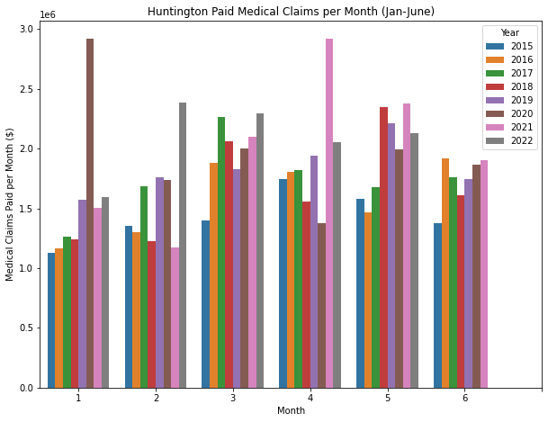

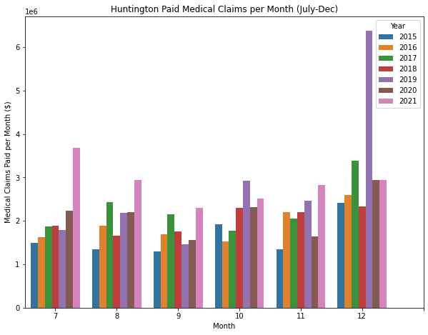

```python
# Visualizing Total Medical Paid Claims by Month
plt.figure(figsize=(10, 7.5))
sns.barplot(data=claims.query('Month <= 6'), x='Month', y='Total Medical Claims', hue='Year')
plt.ylabel('Medical Claims Paid per Month ($)')
plt.xticks(np.arange(0, 7))
plt.title('Huntington Paid Medical Claims per Month (Jan-June)')
plt.show()

plt.figure(figsize=(10, 7.5))
sns.barplot(data=claims.query('Month > 6'), x='Month', y='Total Medical Claims', hue='Year')
plt.ylabel('Medical Claims Paid per Month ($)')
plt.xticks(np.arange(0, 7))
plt.title('Huntington Paid Medical Claims per Month (July-Dec)')
plt.show()
```

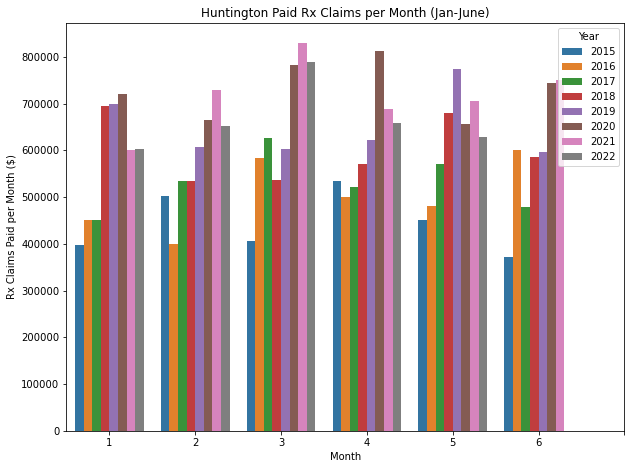

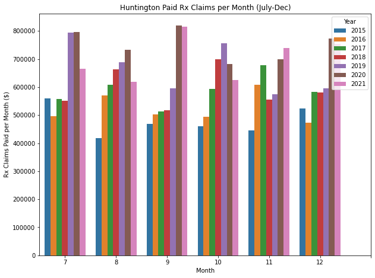

```python
# Visualizing Total Rx Claims
plt.figure(figsize=(10, 7.5))
sns.barplot(data=claims.query('Month <= 6'), x='Month', y='Rx Claims', hue='Year')
plt.ylabel('Rx Claims Paid per Month ($)')
plt.xticks(np.arange(0, 7))
plt.title('Huntington Paid Rx Claims per Month (Jan-June)')
plt.show()

plt.figure(figsize=(10, 7.5))
sns.barplot(data=claims.query('Month > 6'), x='Month', y='Rx Claims', hue='Year')
plt.ylabel('Rx Claims Paid per Month ($)')
plt.xticks(np.arange(0, 7))
plt.title('Huntington Paid Rx Claims per Month (July-Dec)')
plt.show()
```

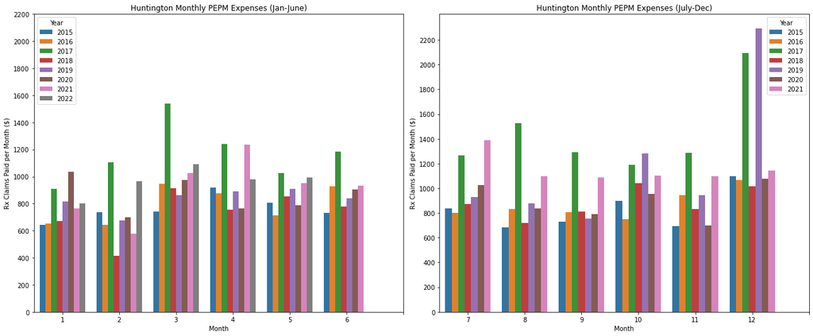

```python
# Visualizing MONTHLY PMPM expenses
plt.figure(figsize=(18, 7.5))
plt.subplot(1, 2, 1)
sns.barplot(data=claims.query('Month <= 6'), x='Month', y='PEPM', hue='Year')
plt.ylabel('Rx Claims Paid per Month ($)')
plt.xticks(np.arange(0, 7))
plt.yticks(np.arange(0, 2400, 200))
plt.title('Huntington Monthly PEPM Expenses (Jan-June)')

plt.subplot(1, 2, 2)
sns.barplot(data=claims.query('Month > 6'), x='Month', y='PEPM', hue='Year')
plt.ylabel('Rx Claims Paid per Month ($)')
plt.xticks(np.arange(0, 7))
plt.yticks(np.arange(0, 2400, 200))
plt.title('Huntington Monthly PEPM Expenses (July-Dec)')

plt.tight_layout()
plt.show()
```

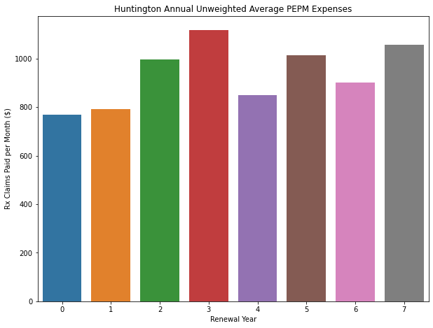

```python
# Visualizing YEARLY PMPM expenses
plt.figure(figsize=(10, 7.5))
sns.barplot(data=claims.groupby('Renewal Year').mean().reset_index(), x='Renewal Year', y='PEPM')
plt.ylabel('Rx Claims Paid per Month ($)')
plt.title('Huntington Annual Unweighted Average PEPM Expenses')
plt.show()
```

*Note: The values in the plot above are unweighted averages as they do not weight each month's PEPM expense by the proportion of Employee Months that are accrued. However, the EE Count remains relatively stable throughout and thus does not actually affect the overall shape of the plot.*

Let's breakdown these plots. The first two barplots visualize monthly Medical Claims paid by Year. Looking at these, we see one major takeaway:

- There appear to be some major outlying months (most obviously 1/20, 2/22, 4/21, 7/21, 12/19)

While this is interesting, it isn't really all that important since we really should be focusing on PMPM or PEPM values.  
The second two barplots are nearly identical to the first two except that they visualize **Rx Claims**. Unsurprisingly, we see some similar trends:

- Values from more recent years seem abnormally high

Like before, this isn't really all that important. The next three plots are much more important as far as this project is concerned. The next two plots visualize Huntington Monthly PEPM Expenses by Year. Like the first four plots, there are certain months which are clearly outliers (most notably 2/17, 2/18, 3/17, 4/17, 4/18, 4/21, 5/17, 6/17, 7/17, 8/17, 9/17, 11/17, 12/17, and 12/19). Since we'll be wanting to Bootstrap using these values, we'll need to replace these outlier values. Below, we will be replacing these values with the average PEPM value between the PEPM expense for the same month of the previous year and the PEPM expense of the same month for the next year. **Should one of the outliers fall in the first or last year in the data, it will not be replaced**. For now, we will manually remove the outliers on Excel and reload the dataset back in.

```python
stripped_claims = pd.read_csv('Huntington Medical Paid Claims Data Outlier Removed.csv')
stripped_claims
```

|  | Month | Year | Renewal Year | Domestic Medical Claims | Non-Domestic Medical Claims | Total Hospital Medical Claims | Non-Hospital Medical Claims | Total Medical Claims | Rx Claims | Rx Rebates | Rx Performance Guarantee | Stop Loss Reimbursement | Adjusted Paid Claims | Member Count | EE Count | PEPM | Unnamed: 16 |
| --- | --- | --- | --- | --- | --- | --- | --- | --- | --- | --- | --- | --- | --- | --- | --- | --- | --- |
| 0 | 1 | 2015 | 0 | 414313.73 | 324468.71 | 738782.44 | 385900.53 | 1124682.97 | 397849.95 | 0.00 | 0.00 | 0.0 | 1522532.92 | 6146 | 2690 | 565.997368 | NaN |
| 1 | 2 | 2015 | 0 | 539505.55 | 307763.94 | 847269.49 | 507899.40 | 1355168.89 | 503271.97 | 67540.50 | 0.00 | 0.0 | 1790900.36 | 6111 | 2716 | 659.388940 | NaN |
| 2 | 3 | 2015 | 0 | 582799.17 | 272127.91 | 854927.08 | 539969.58 | 1394896.66 | 406481.14 | 0.00 | 0.00 | 0.0 | 1801377.80 | 6133 | 2706 | 751.197614 | NaN |
| 3 | 4 | 2015 | 0 | 894533.91 | 253610.74 | 1148144.65 | 593447.65 | 1741592.30 | 533681.67 | 0.00 | 0.00 | 0.0 | 2275273.97 | 6113 | 2699 | 843.006287 | NaN |
| 4 | 5 | 2015 | 0 | 732374.57 | 424912.54 | 1157287.11 | 419625.09 | 1576912.20 | 451070.89 | 66067.50 | 0.00 | 0.0 | 1961915.59 | 6114 | 2683 | 731.239504 | NaN |
| ... | ... | ... | ... | ... | ... | ... | ... | ... | ... | ... | ... | ... | ... | ... | ... | ... | ... |
| 84 | 1 | 2022 | 7 | 501463.78 | 474951.54 | 976415.32 | 619224.78 | 1595640.10 | 603637.45 | 0.00 | 0.00 | 0.0 | 2199277.55 | 6622 | 3145 | 699.293339 | NaN |
| 85 | 2 | 2022 | 7 | 702513.46 | 541335.00 | 1243848.46 | 1140214.23 | 2384062.69 | 650981.28 | 370485.73 | 0.00 | 0.0 | 2664558.24 | 6612 | 3092 | 861.758810 | NaN |
| 86 | 3 | 2022 | 7 | 760937.71 | 588458.73 | 1349396.44 | 943089.50 | 2292485.94 | 788584.54 | 0.00 | 11435.00 | 0.0 | 3069635.48 | 6643 | 3111 | 986.703787 | NaN |
| 87 | 4 | 2022 | 7 | 579591.91 | 513879.57 | 1093471.48 | 963612.60 | 2057084.08 | 659029.75 | 0.00 | 0.00 | 0.0 | 2716113.83 | 6588 | 3108 | 873.910499 | NaN |
| 88 | 5 | 2022 | 7 | 462605.24 | 651661.71 | 1114266.95 | 1016179.46 | 2130446.41 | 627878.54 | 0.00 | 11250.05 | 0.0 | 2747074.90 | 6618 | 3093 | 888.158713 | NaN |

89 rows × 17 columns

Now let's recreate the visualizations from before:

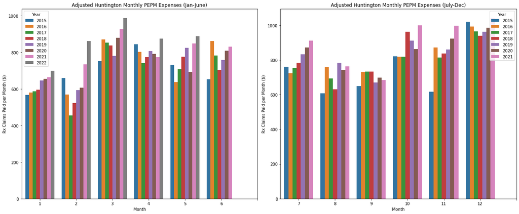

```python
# Visualizing MONTHLY PMPM expenses
plt.figure(figsize=(18, 7.5))
plt.subplot(1, 2, 1)
sns.barplot(data=stripped_claims.query('Month <= 6'), x='Month', y='PEPM', hue='Year')
plt.ylabel('Rx Claims Paid per Month ($)')
plt.xticks(np.arange(0, 7))
plt.title('Adjusted Huntington Monthly PEPM Expenses (Jan-June)')

plt.subplot(1, 2, 2)
sns.barplot(data=stripped_claims.query('Month > 6'), x='Month', y='PEPM', hue='Year')
plt.ylabel('Rx Claims Paid per Month ($)')
plt.xticks(np.arange(0, 7))
plt.title('Adjusted Huntington Monthly PEPM Expenses (July-Dec)')

plt.tight_layout()
plt.show()
```

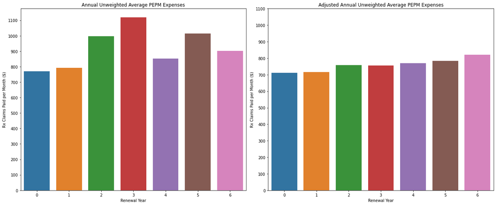

```python
# Side-by-side comparison of actual and adjusted values
plt.figure(figsize=(18, 7.5))
plt.subplot(1, 2, 1)
sns.barplot(data=claims.query('`Renewal Year` != 7').groupby('Renewal Year').mean().reset_index(), x='Renewal Year', y='PEPM')
plt.ylabel('Rx Claims Paid per Month ($)')
plt.yticks(np.arange(0, 1200, 100))
plt.title('Annual Unweighted Average PEPM Expenses')

plt.subplot(1, 2, 2)
sns.barplot(data=stripped_claims.query('`Renewal Year` != 7').groupby('Renewal Year').mean().reset_index(), x='Renewal Year', y='PEPM')
plt.ylabel('Rx Claims Paid per Month ($)')
plt.yticks(np.arange(0, 1200, 100))
plt.title('Adjusted Annual Unweighted Average PEPM Expenses')
plt.tight_layout()
plt.show()
```

*Note: The values in the plot above are unweighted averages as they do not weight each month's PEPM expense by the proportion of Employee Months that are accrued. However, the EE Count remains relatively stable throughout and thus does not actually affect the overall shape of the plot.*

The plot to the right look much better, we'll go ahead and use this fixed up data (`stripped_claims`) to train our model.

## Model Creation

```python
# Generating resamples
resampled_months = pd.DataFrame(columns=['Month',
                                         'Year'])
for num in np.arange(1, 13):
    for i in np.arange(1000):
        each_month = stripped_claims.query('Month == @num and Year <= 2021')
        month = [num, num, num, num, num, num, num]
        year = [2015, 2016, 2017, 2018, 2019, 2020, 2021]
        df = {'Month': month, 'Year': year}
        resampled = pd.DataFrame(data=df)
        resample = each_month[['EE Count', 'PEPM']].sample(frac=1, replace=True, axis=0).reset_index().drop('index', axis=1)
        resampled['EE Count'] = resample['EE Count']
        resampled['PEPM'] = resample['PEPM']
        resampled_months = resampled_months.append(resampled)
resampled_months = resampled_months.reset_index().drop('index', axis=1).dropna()

# Further data transformations
def add_renewal_year(month, year):
    '''
    Function that returns a list of the corresponding Renewal Year for Huntington Medical Group
    -----
    Inputs:

    month (Python list) - Month column in resampled_months DataFrame

    year (Python list) - Year column in resampled_months DataFrame
    -----
    Output:

    renewal_year (Python list) - Corresponding renewal year column to be added to the
                                 resampled_months DataFrame
    '''
    renewal_year = []
    for i in np.arange(0, len(month)):
        if month[i] <= 5 and year[i] == 2015:
            renewal_year.append(0)
        elif month[i] >= 6 and year[i] == 2015:
            renewal_year.append(1)
        elif month[i] <=5 and year[i] == 2016:
            renewal_year.append(1)
        elif month[i] >= 6 and year[i] == 2016:
            renewal_year.append(2)
        elif month[i] <= 5 and year[i] == 2017:
            renewal_year.append(2)
        elif month[i] >= 6 and year[i] == 2017:
            renewal_year.append(3)
        elif month[i] <= 5 and year[i] == 2018:
            renewal_year.append(3)
        elif month[i] >= 6 and year[i] == 2018:
            renewal_year.append(4)
        elif month[i] <= 5 and year[i] == 2019:
            renewal_year.append(4)
        elif month[i] >= 6 and year[i] == 2019:
            renewal_year.append(5)
        elif month[i] <= 5 and year[i] == 2020:
            renewal_year.append(5)
        elif month[i] >= 6 and year[i] == 2020:
            renewal_year.append(6)
        elif month[i] <= 5 and year[i] == 2021:
            renewal_year.append(6)
        elif month[i] >= 6 and year[i] == 2021:
            renewal_year.append(7)
        elif month[i] <= 5 and year[i] == 2022:
            renewal_year.append(7)
        else:
            renewal_year.append(10)
    return renewal_year
resampled_months['Renewal Year'] = add_renewal_year(resampled_months['Month'].values, \
                                                    resampled_months['Year'].values)
resampled_months
```

|  | Month | Year | EE Count | PEPM | Renewal Year |
| --- | --- | --- | --- | --- | --- |
| 0 | 1 | 2015 | 3174.0 | 664.330413 | 0 |
| 1 | 1 | 2016 | 3020.0 | 587.191524 | 1 |
| 2 | 1 | 2017 | 2690.0 | 565.997368 | 2 |
| 3 | 1 | 2018 | 2781.0 | 579.693833 | 3 |
| 4 | 1 | 2019 | 3020.0 | 587.191524 | 4 |
| ... | ... | ... | ... | ... | ... |
| 83995 | 12 | 2017 | 3128.0 | 1041.966809 | 3 |
| 83996 | 12 | 2018 | 3128.0 | 1041.966809 | 4 |
| 83997 | 12 | 2019 | 3107.0 | 940.140283 | 5 |
| 83998 | 12 | 2020 | 3107.0 | 940.140283 | 6 |
| 83999 | 12 | 2021 | 3001.0 | 991.919943 | 7 |

84000 rows × 5 columns

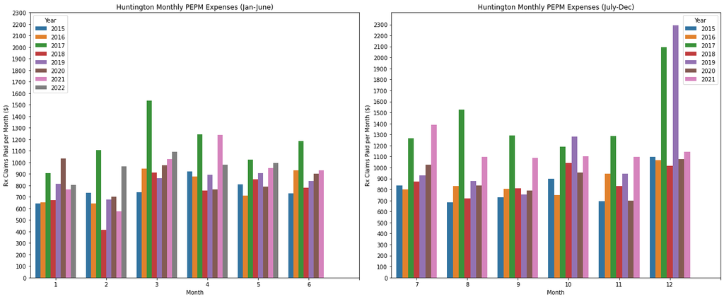

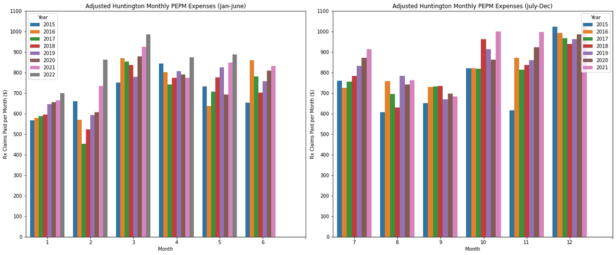

```python
# Visualizing monthly PMPM expenses
plt.figure(figsize=(18, 7.5))
plt.subplot(1, 2, 1)
sns.barplot(data=claims.query('Month <= 6'), x='Month', y='PEPM', hue='Year')
plt.ylabel('Rx Claims Paid per Month ($)')
plt.xticks(np.arange(0, 7))
plt.yticks(np.arange(0, 2400, 100))
plt.title('Huntington Monthly PEPM Expenses (Jan-June)')

plt.subplot(1, 2, 2)
sns.barplot(data=claims.query('Month > 6'), x='Month', y='PEPM', hue='Year')
plt.ylabel('Rx Claims Paid per Month ($)')
plt.xticks(np.arange(0, 7))
plt.yticks(np.arange(0, 2400, 100))
plt.title('Huntington Monthly PEPM Expenses (July-Dec)')

plt.tight_layout()
plt.show()

# Plot side-by-side adjusted monthly PEPM
plt.figure(figsize=(18, 7.5))
plt.subplot(1, 2, 1)
sns.barplot(data=stripped_claims.query('Month <= 6'), x='Month', y='PEPM', hue='Year')
plt.ylabel('Rx Claims Paid per Month ($)')
plt.xticks(np.arange(0, 7))
plt.yticks(np.arange(0, 1200, 100))
plt.title('Adjusted Huntington Monthly PEPM Expenses (Jan-June)')

plt.subplot(1, 2, 2)
sns.barplot(data=stripped_claims.query('Month > 6'), x='Month', y='PEPM', hue='Year')
plt.ylabel('Rx Claims Paid per Month ($)')
plt.xticks(np.arange(0, 7))
plt.yticks(np.arange(0, 1200, 100))
plt.title('Adjusted Huntington Monthly PEPM Expenses (July-Dec)')

plt.tight_layout(pad=1)
plt.show()
```

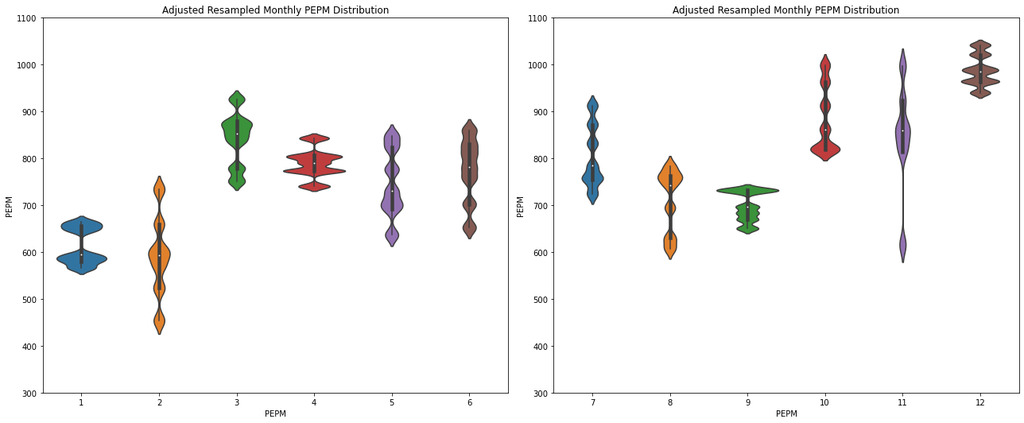

```python
# Violin plots for January-June
plt.figure(figsize=(18, 7.5))
plt.subplot(1, 2, 1)
sns.violinplot(data=resampled_months.query('Month <= 6'), x='Month', y='PEPM')
plt.xlabel('PEPM')
plt.yticks(np.arange(300, 1200, 100))
plt.title('Adjusted Resampled Monthly PEPM Distribution')

# Violin plots for July-December
plt.subplot(1, 2, 2)
sns.violinplot(data=resampled_months.query('Month > 6'), x='Month', y='PEPM')
plt.xlabel('PEPM')
plt.yticks(np.arange(300, 1200, 100))
plt.title('Adjusted Resampled Monthly PEPM Distribution')

plt.tight_layout()
plt.show()
```

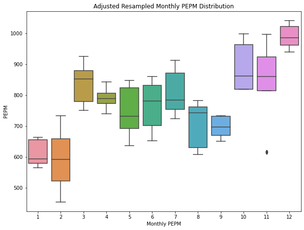

```python
# Boxplot version of the above
plt.figure(figsize=(10, 7.5))
sns.boxplot(data=resampled_months, x='Month', y='PEPM')
plt.xlabel('Monthly PEPM')
plt.title('Adjusted Resampled Monthly PEPM Distribution')
plt.show()
```

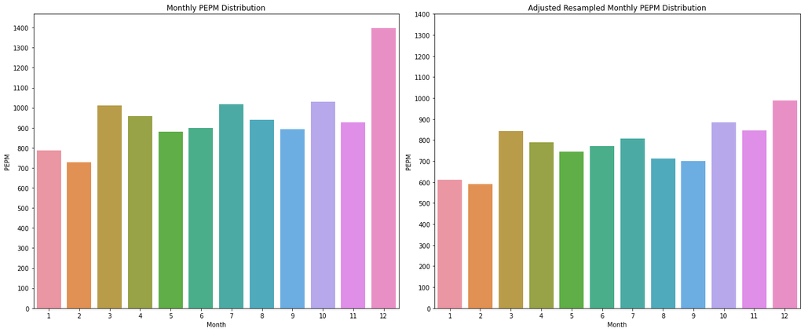

```python
# Side-by-side mean monthly PEPM
plt.figure(figsize=(18, 7.5))
plt.subplot(1, 2, 1)
sns.barplot(data=claims.groupby('Month').mean().reset_index(), x='Month', y='PEPM')
plt.xlabel('Month')
plt.yticks(np.arange(0, 1500, 100))
plt.title('Monthly PEPM Distribution')

# Violin plots for July-December
plt.subplot(1, 2, 2)
sns.barplot(data=resampled_months.groupby('Month').mean().reset_index(), x='Month', y='PEPM')
plt.xlabel('Month')
plt.yticks(np.arange(0, 1500, 100))
plt.title('Adjusted Resampled Monthly PEPM Distribution')

plt.tight_layout()
plt.show()
```

```python
def resampled_yearly_pepm(renewal_year, n):
    '''
    Extracts the average PEPM value from the resampled_months DataFrame
    for the specified year
    -----
    Input:

    renewal_year (int) - Int value specifying the renewal year to extract

    n (int) - Number of resamples
    -----
    Output:

    pepm_ryr (NumPy Array) - NumPy Array of length n (where n is the number of resamples)
                             with the yearly mean PEPM values
    '''
    ryr = resampled_months.sort_values(['Year', 'Month']) \
                          .query('`Renewal Year` == @renewal_year')
    pepm_arr_ryr = ryr['PEPM'].values
    ee_arr_ryr = ryr['EE Count'].values
    pepm_arr_ryr_split = np.split(pepm_arr_ryr, 12)
    ee_arr_ryr_split = np.split(ee_arr_ryr, 12)
    ee_sums = [sum(item) for item in ee_arr_ryr_split]
    ee_sums = np.zeros(n)
    for i in range(len(ee_arr_ryr_split)):
        ee_sums += ee_arr_ryr_split[i]
    ee_props = [ee_arr_ryr_split[i] / ee_sums for i in range(len(ee_arr_ryr_split))]
    weighted_totals = [np.multiply(ee_props[i], pepm_arr_ryr_split[i]) for i in range(len(ee_props))]
    pepm_ryr = np.zeros(n)
    for i in range(len(weighted_totals)):
        pepm_ryr += weighted_totals[i]
    return pepm_ryr
```

```python
pepm_ryr2 = resampled_yearly_pepm(2, 1000)
pepm_ryr3 = resampled_yearly_pepm(3, 1000)
pepm_ryr4 = resampled_yearly_pepm(4, 1000)
pepm_ryr5 = resampled_yearly_pepm(5, 1000)
```

```
p-value: 0.168
```

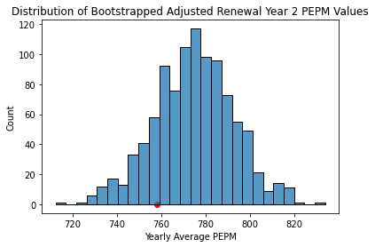

```
p-value: 0.136
```

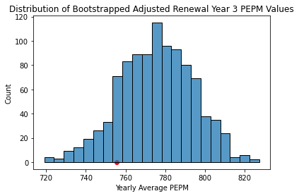

```
p-value: 0.373
```

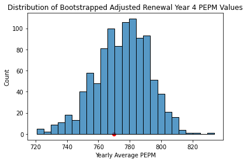

```
p-value: 0.342
```

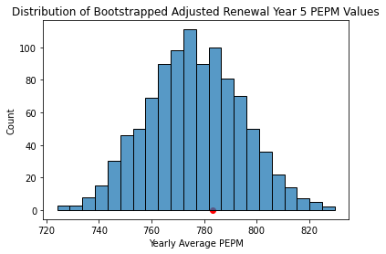

```python
pepms = [pepm_ryr2, pepm_ryr3, pepm_ryr4, pepm_ryr5]
observed_yearly_pepms = stripped_claims.query('`Renewal Year` > 1 and `Renewal Year` < 6') \
                                       .groupby('Renewal Year').mean()['PEPM'].values
i = 0
start = 2
for pepm in pepms:
    observed_year_pepm = observed_yearly_pepms[i]
    sns.histplot(data=pepm)
    plt.xlabel('Yearly Average PEPM')
    plt.title(f'Distribution of Bootstrapped Adjusted Renewal Year {start} PEPM Values')
    plt.scatter(observed_year_pepm, -0.01, color='red')
    print(f'p-value: {min(sum(pepms[i] >= observed_year_pepm) / len(pepms[i]), sum(pepms[i] <= observed_year_pepm) / len(pepms[i]))}')
    plt.show()
    i += 1
    start += 1
```

Looking at the plots above and their corresponding p-values, we see that the bootsrapping process has both built an approximately normal distribution of PEPM values for each Renewal Year (Years 2-5 in our case) and has approximately rebuilt the population. We can say this because the observed averages are well within the distribution (i.e. the chance of mistakenly characterizing the observed value as statistically sigificant is high). Now we'll need to perform a series of data transformations to form the dataset we'll be using to train our model.

```python
actual = resampled_months.query('`Renewal Year` == 5').sort_values(['Year', 'Month'])
pepm_arr_ryr = actual['PEPM'].values
ee_arr_ryr = actual['EE Count'].values
pepm_arr_ryr_split = np.split(pepm_arr_ryr, 12)
ee_arr_ryr_split = np.split(ee_arr_ryr, 12)
ee_sums = [sum(item) for item in ee_arr_ryr_split]
ee_sums = np.zeros(1000)
for i in range(len(ee_arr_ryr_split)):
    ee_sums += ee_arr_ryr_split[i]
ee_props = [ee_arr_ryr_split[i] / ee_sums for i in range(len(ee_arr_ryr_split))]
weighted_totals = [np.multiply(ee_props[i], pepm_arr_ryr_split[i]) for i in range(len(ee_props))]
actual_pepm = np.zeros(1000)
for i in range(len(weighted_totals)):
    actual_pepm += weighted_totals[i]
```

```python
renewal_yr1 = np.split(resampled_months.query('`Renewal Year` == 2').sort_values(['Year', 'Month'])['PEPM'].values, 12)
renewal_yr2 = np.split(resampled_months.query('`Renewal Year` == 3').sort_values(['Year', 'Month'])['PEPM'].values, 12)
renewal_yr3 = np.split(resampled_months.query('`Renewal Year` == 4').sort_values(['Year', 'Month'])['PEPM'].values, 12)
design_matrix = pd.DataFrame(data={'Month 1': renewal_yr1[0], 'Month 2': renewal_yr1[1],
                                   'Month 3': renewal_yr1[2], 'Month 4': renewal_yr1[3],
                                   'Month 5': renewal_yr1[4], 'Month 6': renewal_yr1[5],
                                   'Month 7': renewal_yr1[6], 'Month 8': renewal_yr1[7],
                                   'Month 8': renewal_yr1[8], 'Month 9': renewal_yr1[9],
                                   'Month 10': renewal_yr1[10], 'Month 11': renewal_yr1[11],
                                   'Month 12': renewal_yr2[0], 'Month 13': renewal_yr2[1],
                                   'Month 14': renewal_yr2[2], 'Month 15': renewal_yr2[3],
                                   'Month 16': renewal_yr2[4], 'Month 17': renewal_yr2[5],
                                   'Month 18': renewal_yr2[6], 'Month 19': renewal_yr2[7],
                                   'Month 20': renewal_yr2[8], 'Month 21': renewal_yr2[9],
                                   'Month 22': renewal_yr2[10], 'Month 23':renewal_yr2[11],
                                   'Month 24': renewal_yr3[0], 'Month 25': renewal_yr3[1],
                                   'Month 26': renewal_yr3[2], 'Month 27': renewal_yr3[3],
                                   'Month 28': renewal_yr3[4], 'Month 29': renewal_yr3[5],
                                   'Month 30': renewal_yr3[6], 'Month 31': renewal_yr3[7],
                                   'Month 32': renewal_yr3[8], 'Month 33': renewal_yr3[9],
                                   'Month 34': renewal_yr3[10], 'Month 35': renewal_yr3[11],
                                   'Following Year Average PEPM': actual_pepm})
design_matrix
```

|  | Month 1 | Month 2 | Month 3 | Month 4 | Month 5 | Month 6 | Month 7 | Month 8 | Month 9 | Month 10 | ... | Month 27 | Month 28 | Month 29 | Month 30 | Month 31 | Month 32 | Month 33 | Month 34 | Month 35 | Following Year Average PEPM |
| --- | --- | --- | --- | --- | --- | --- | --- | --- | --- | --- | --- | --- | --- | --- | --- | --- | --- | --- | --- | --- | --- |
| 0 | 652.563948 | 784.289329 | 694.596059 | 697.144312 | 820.651995 | 871.129612 | 966.030113 | 734.022439 | 778.846267 | 801.607736 | ... | 697.144312 | 963.136584 | 923.611905 | 1021.661951 | 587.191524 | 569.691433 | 869.190770 | 740.408780 | 706.539316 | 774.839246 |
| 1 | 831.153148 | 912.692280 | 607.579188 | 729.748314 | 820.651995 | 923.611905 | 940.140283 | 453.848858 | 879.691395 | 740.408780 | ... | 729.748314 | 820.651995 | 871.129612 | 985.160269 | 565.997368 | 453.848858 | 879.691395 | 843.006287 | 706.539316 | 790.808597 |
| 2 | 702.351556 | 832.004270 | 607.579188 | 731.902108 | 818.841053 | 836.849738 | 985.160269 | 569.691433 | 751.197614 | 773.141579 | ... | 731.902108 | 912.600062 | 997.168487 | 966.030113 | 655.335464 | 592.667177 | 869.190770 | 789.862151 | 692.180479 | 758.263281 |
| 3 | 757.194834 | 754.368547 | 783.151979 | 731.902108 | 963.136584 | 871.129612 | 940.140283 | 453.848858 | 852.756765 | 773.495752 | ... | 683.296007 | 963.136584 | 871.129612 | 940.140283 | 655.335464 | 592.667177 | 869.190770 | 773.141579 | 776.423408 | 782.160494 |
| 4 | 860.513329 | 754.368547 | 630.378131 | 734.055902 | 999.040080 | 836.849738 | 966.030113 | 569.691433 | 926.147536 | 740.408780 | ... | 669.447702 | 819.746524 | 813.685789 | 1021.661951 | 565.997368 | 606.286068 | 869.190770 | 773.141579 | 636.655225 | 798.691413 |
| ... | ... | ... | ... | ... | ... | ... | ... | ... | ... | ... | ... | ... | ... | ... | ... | ... | ... | ... | ... | ... | ... |
| 995 | 652.563948 | 872.348275 | 694.596059 | 731.902108 | 820.651995 | 860.013687 | 1021.661951 | 606.286068 | 751.197614 | 740.408780 | ... | 697.144312 | 818.841053 | 997.168487 | 940.140283 | 594.689216 | 523.258018 | 926.147536 | 789.862151 | 776.423408 | 764.746155 |
| 996 | 831.153148 | 784.289329 | 607.579188 | 734.055902 | 862.063540 | 836.849738 | 940.140283 | 523.258018 | 836.322759 | 843.006287 | ... | 669.447702 | 862.063540 | 836.849738 | 991.919943 | 587.191524 | 659.388940 | 926.147536 | 843.006287 | 692.180479 | 777.210257 |
| 997 | 781.432442 | 760.263674 | 694.596059 | 731.902108 | 912.600062 | 813.685789 | 1041.966809 | 734.022439 | 778.846267 | 789.862151 | ... | 729.748314 | 819.746524 | 836.849738 | 985.160269 | 579.693833 | 523.258018 | 751.197614 | 789.862151 | 848.402127 | 803.445200 |
| 998 | 860.513329 | 784.289329 | 742.539715 | 734.055902 | 963.136584 | 997.168487 | 1041.966809 | 592.667177 | 852.756765 | 773.141579 | ... | 731.902108 | 819.746524 | 836.849738 | 966.030113 | 646.340514 | 734.022439 | 751.197614 | 806.582724 | 776.423408 | 782.047777 |
| 999 | 860.513329 | 760.263674 | 630.378131 | 650.450107 | 818.841053 | 860.013687 | 966.030113 | 659.388940 | 852.756765 | 789.862151 | ... | 734.055902 | 862.063540 | 813.685789 | 1041.966809 | 594.689216 | 523.258018 | 836.322759 | 801.607736 | 731.239504 | 757.502746 |

1000 rows × 36 columns

## Training the Model

```
Validation MSE: Following Year Average PEPM    18.88676
dtype: float64
Test MSE: Following Year Average PEPM    20.098472
dtype: float64
753.053372689964
802.0825538006554
```

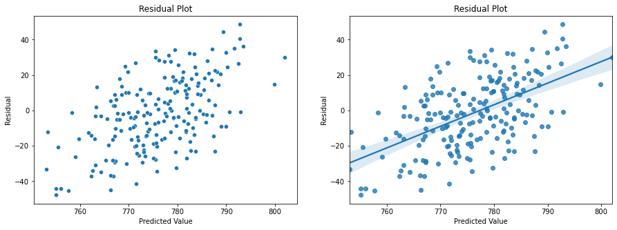

```
Correlation: 0.5536654300626992
```

```python
# Model Selection
from sklearn import model_selection, linear_model

# Split into train and test sets
X = design_matrix.drop('Following Year Average PEPM', axis=1)
Y = design_matrix[['Following Year Average PEPM']]
X_train, X_test, Y_train, Y_test = model_selection.train_test_split(X, Y, test_size=0.2)

# Train the model
kf = model_selection.KFold(n_splits=5)
kf_lr_models = []
validation_errors = []

for train_idx, valid_idx in kf.split(X_train):
    # Split the data
    split_X_train = X_train.iloc[train_idx].iloc[:, 4:]
    split_X_valid = X_train.iloc[valid_idx].iloc[:, 4:]
    split_Y_train = Y_train.iloc[train_idx]
    split_Y_valid = Y_train.iloc[valid_idx]

    # Create and fit a Logistic Regression model on the training split
    model = linear_model.LinearRegression(fit_intercept=False)
    model.fit(split_X_train, split_Y_train)

    # Compute the Mean Cross Entropy Loss on the validation split
    thetas = model.coef_.flatten()
    mse = np.mean((model.predict(split_X_train) - split_Y_train.to_numpy()) ** 2)

    kf_lr_models.append(model)
    validation_errors.append(mse)

lowest_validation_error = min(validation_errors)
index = 0
for error in validation_errors:
    if validation_errors[index] == lowest_validation_error:
        break
    else:
        index += 1
optimal_model = kf_lr_models[index]

# Model validation
optimal_model.fit(X_train, Y_train)
validation_predictions = optimal_model.predict(X_train)
test_predictions = optimal_model.predict(X_test)

model_validation_error = (np.mean((validation_predictions - Y_train) ** 2)) ** 0.5
model_test_error = (np.mean((test_predictions - Y_test) ** 2)) ** 0.5
print(f'Validation MSE: {model_validation_error}')
print(f'Test MSE: {model_test_error}')
print(min(test_predictions.flatten()))
print(max(test_predictions.flatten()))

# Plotting the residuals
residuals = test_predictions.flatten() - Y_test.values.flatten()
residuals_df = pd.DataFrame(data={'Predicted Value': test_predictions.flatten(), 'Residual': residuals})

plt.figure(figsize=(15, 5))
plt.subplot(1, 2, 1)
sns.scatterplot(data=residuals_df, x='Predicted Value', y='Residual')
plt.title('Residual Plot')

plt.subplot(1, 2, 2)
sns.regplot(data=residuals_df, x='Predicted Value', y='Residual')
plt.title('Residual Plot')

plt.show()
print(f'Correlation: {residuals_df.corr()["Residual"].values[0]}')
```

```python
pd.DataFrame(data={'Test Predictions': test_predictions.flatten(), 'Actual Values': Y_test.values.flatten()})
```

|  | Test Predictions | Actual Values |
| --- | --- | --- |
| 0 | 773.482287 | 787.852224 |
| 1 | 771.283124 | 791.589224 |
| 2 | 773.372403 | 799.384913 |
| 3 | 765.265092 | 793.566417 |
| 4 | 787.119017 | 752.245740 |
| ... | ... | ... |
| 195 | 762.554192 | 796.663500 |
| 196 | 779.558833 | 762.503281 |
| 197 | 781.848507 | 772.510741 |
| 198 | 778.489013 | 772.983564 |
| 199 | 755.565045 | 776.334062 |

200 rows × 2 columns

```
Test RMSE: 19.447837484101147
Min: 745.8005994281012
Max: 813.3760502410994
```

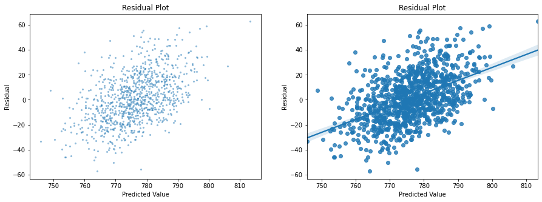

```
Correlation: 0.4900671230373313
```

```python
# Years 1, 2, and 3 predicting 4
pepm_arr_ryr = resampled_months.query('`Renewal Year` == 4')['PEPM'].values
ee_arr_ryr = resampled_months.query('`Renewal Year` == 4')['EE Count'].values
pepm_arr_ryr_split = np.split(pepm_arr_ryr, 12)
ee_arr_ryr_split = np.split(ee_arr_ryr, 12)
ee_sums = [sum(item) for item in ee_arr_ryr_split]
ee_sums = np.zeros(1000)
for i in range(len(ee_arr_ryr_split)):
    ee_sums += ee_arr_ryr_split[i]
ee_props = [ee_arr_ryr_split[i] / ee_sums for i in range(len(ee_arr_ryr_split))]
weighted_totals = [np.multiply(ee_props[i], pepm_arr_ryr_split[i]) for i in range(len(ee_props))]
actual_pepm = np.zeros(1000)
for i in range(len(weighted_totals)):
    actual_pepm += weighted_totals[i]
Y_test2 = actual_pepm

renewal_yr1 = np.split(resampled_months.query('`Renewal Year` == 1').sort_values(['Year', 'Month'])['PEPM'].values, 12)
renewal_yr2 = np.split(resampled_months.query('`Renewal Year` == 2').sort_values(['Year', 'Month'])['PEPM'].values, 12)
renewal_yr3 = np.split(resampled_months.query('`Renewal Year` == 3').sort_values(['Year', 'Month'])['PEPM'].values, 12)
design_matrix2 = pd.DataFrame(data={'Month 1': renewal_yr1[0], 'Month 2': renewal_yr1[1],
                                   'Month 3': renewal_yr1[2], 'Month 4': renewal_yr1[3],
                                   'Month 5': renewal_yr1[4], 'Month 6': renewal_yr1[5],
                                   'Month 7': renewal_yr1[6], 'Month 8': renewal_yr1[7],
                                   'Month 8': renewal_yr1[8], 'Month 9': renewal_yr1[9],
                                   'Month 10': renewal_yr1[10], 'Month 11': renewal_yr1[11],
                                   'Month 12': renewal_yr2[0], 'Month 13': renewal_yr2[1],
                                   'Month 14': renewal_yr2[2], 'Month 15': renewal_yr2[3],
                                   'Month 16': renewal_yr2[4], 'Month 17': renewal_yr2[5],
                                   'Month 18': renewal_yr2[6], 'Month 19': renewal_yr2[7],
                                   'Month 20': renewal_yr2[8], 'Month 21': renewal_yr2[9],
                                   'Month 22': renewal_yr2[10], 'Month 23':renewal_yr2[11],
                                   'Month 24': renewal_yr3[0], 'Month 25': renewal_yr3[1],
                                   'Month 26': renewal_yr3[2], 'Month 27': renewal_yr3[3],
                                   'Month 28': renewal_yr3[4], 'Month 29': renewal_yr3[5],
                                   'Month 30': renewal_yr3[6], 'Month 31': renewal_yr3[7],
                                   'Month 32': renewal_yr3[8], 'Month 33': renewal_yr3[9],
                                   'Month 34': renewal_yr3[10], 'Month 35': renewal_yr3[11]})

test_predictions = optimal_model.predict(design_matrix2)
model_test_error = (np.mean((test_predictions - Y_test2) ** 2)) ** 0.5
print(f'Test RMSE: {model_test_error}')
print(f'Min: {min(test_predictions.flatten())}')
print(f'Max: {max(test_predictions.flatten())}')

residuals = test_predictions.flatten() - Y_test2.flatten()
residuals_df = pd.DataFrame(data={'Predicted Value': test_predictions.flatten(), 'Residual': residuals})

plt.figure(figsize=(15, 5))
plt.subplot(1, 2, 1)
sns.scatterplot(data=residuals_df, x='Predicted Value', y='Residual', s=10, alpha=0.5)
plt.title('Residual Plot')

plt.subplot(1, 2, 2)
sns.regplot(data=residuals_df, x='Predicted Value', y='Residual')
plt.title('Residual Plot')

plt.show()
print(f'Correlation: {residuals_df.corr()["Residual"].values[0]}')
```

```
Test RMSE: 19.826978219776507
Min: 750.4943426067304
Max: 802.0825538006554
```

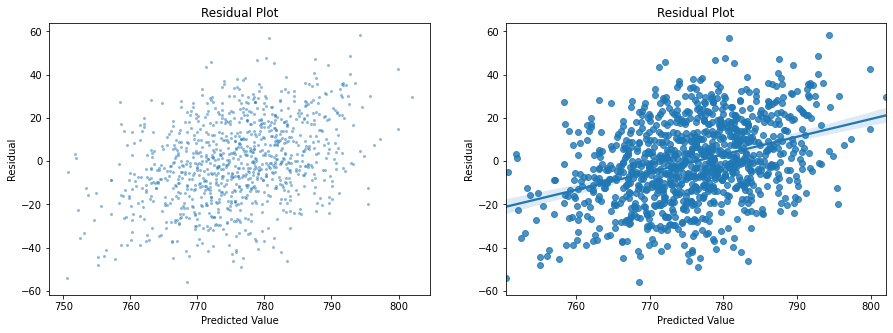

```
Correlation: 0.3703122549343738
```

```python
# Years 2, 3, and 4 predicting 5
pepm_arr_ryr = resampled_months.query('`Renewal Year` == 5')['PEPM'].values
ee_arr_ryr = resampled_months.query('`Renewal Year` == 5')['EE Count'].values
pepm_arr_ryr_split = np.split(pepm_arr_ryr, 12)
ee_arr_ryr_split = np.split(ee_arr_ryr, 12)
ee_sums = [sum(item) for item in ee_arr_ryr_split]
ee_sums = np.zeros(1000)
for i in range(len(ee_arr_ryr_split)):
    ee_sums += ee_arr_ryr_split[i]
ee_props = [ee_arr_ryr_split[i] / ee_sums for i in range(len(ee_arr_ryr_split))]
weighted_totals = [np.multiply(ee_props[i], pepm_arr_ryr_split[i]) for i in range(len(ee_props))]
actual_pepm = np.zeros(1000)
for i in range(len(weighted_totals)):
    actual_pepm += weighted_totals[i]
Y_test2 = actual_pepm

renewal_yr1 = np.split(resampled_months.query('`Renewal Year` == 2').sort_values(['Year', 'Month'])['PEPM'].values, 12)
renewal_yr2 = np.split(resampled_months.query('`Renewal Year` == 3').sort_values(['Year', 'Month'])['PEPM'].values, 12)
renewal_yr3 = np.split(resampled_months.query('`Renewal Year` == 4').sort_values(['Year', 'Month'])['PEPM'].values, 12)
design_matrix2 = pd.DataFrame(data={'Month 1': renewal_yr1[0], 'Month 2': renewal_yr1[1],
                                   'Month 3': renewal_yr1[2], 'Month 4': renewal_yr1[3],
                                   'Month 5': renewal_yr1[4], 'Month 6': renewal_yr1[5],
                                   'Month 7': renewal_yr1[6], 'Month 8': renewal_yr1[7],
                                   'Month 8': renewal_yr1[8], 'Month 9': renewal_yr1[9],
                                   'Month 10': renewal_yr1[10], 'Month 11': renewal_yr1[11],
                                   'Month 12': renewal_yr2[0], 'Month 13': renewal_yr2[1],
                                   'Month 14': renewal_yr2[2], 'Month 15': renewal_yr2[3],
                                   'Month 16': renewal_yr2[4], 'Month 17': renewal_yr2[5],
                                   'Month 18': renewal_yr2[6], 'Month 19': renewal_yr2[7],
                                   'Month 20': renewal_yr2[8], 'Month 21': renewal_yr2[9],
                                   'Month 22': renewal_yr2[10], 'Month 23':renewal_yr2[11],
                                   'Month 24': renewal_yr3[0], 'Month 25': renewal_yr3[1],
                                   'Month 26': renewal_yr3[2], 'Month 27': renewal_yr3[3],
                                   'Month 28': renewal_yr3[4], 'Month 29': renewal_yr3[5],
                                   'Month 30': renewal_yr3[6], 'Month 31': renewal_yr3[7],
                                   'Month 32': renewal_yr3[8], 'Month 33': renewal_yr3[9],
                                   'Month 34': renewal_yr3[10], 'Month 35': renewal_yr3[11]})

test_predictions = optimal_model.predict(design_matrix2)
model_test_error = (np.mean((test_predictions - Y_test2) ** 2)) ** 0.5
print(f'Test RMSE: {model_test_error}')
print(f'Min: {min(test_predictions.flatten())}')
print(f'Max: {max(test_predictions.flatten())}')

residuals = test_predictions.flatten() - Y_test2.flatten()
residuals_df = pd.DataFrame(data={'Predicted Value': test_predictions.flatten(), 'Residual': residuals})

plt.figure(figsize=(15, 5))
plt.subplot(1, 2, 1)
sns.scatterplot(data=residuals_df, x='Predicted Value', y='Residual', s=10, alpha=0.5)
plt.title('Residual Plot')

plt.subplot(1, 2, 2)
sns.regplot(data=residuals_df, x='Predicted Value', y='Residual')
plt.title('Residual Plot')

plt.show()
print(f'Correlation: {residuals_df.corr()["Residual"].values[0]}')
```

```
Test RMSE: 19.949740444256758
Min: 748.5274099239595
Max: 803.8943201213798
```

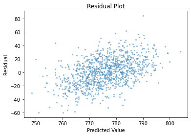

```
Correlation: 0.4608218629389859
```

```python
# Years 3, 4, and 5 predicting 6
three_plus = resampled_months.query('`Renewal Year` > 2 and `Renewal Year` < 7')
pepm_arr_ryr = three_plus.query('`Renewal Year` == 6')['PEPM'].values
ee_arr_ryr = three_plus.query('`Renewal Year` == 6')['EE Count'].values
pepm_arr_ryr_split = np.split(pepm_arr_ryr, 12)
ee_arr_ryr_split = np.split(ee_arr_ryr, 12)
ee_sums = [sum(item) for item in ee_arr_ryr_split]
ee_sums = np.zeros(1000)
for i in range(len(ee_arr_ryr_split)):
    ee_sums += ee_arr_ryr_split[i]
ee_props = [ee_arr_ryr_split[i] / ee_sums for i in range(len(ee_arr_ryr_split))]
weighted_totals = [np.multiply(ee_props[i], pepm_arr_ryr_split[i]) for i in range(len(ee_props))]
actual_pepm = np.zeros(1000)
for i in range(len(weighted_totals)):
    actual_pepm += weighted_totals[i]
Y_test3 = actual_pepm

renewal_yr3 = np.split(resampled_months.query('`Renewal Year` == 3').sort_values(['Year', 'Month'])['PEPM'].values, 12)
renewal_yr4 = np.split(resampled_months.query('`Renewal Year` == 4').sort_values(['Year', 'Month'])['PEPM'].values, 12)
renewal_yr5 = np.split(resampled_months.query('`Renewal Year` == 5').sort_values(['Year', 'Month'])['PEPM'].values, 12)
design_matrix3 = pd.DataFrame(data={'Month 1': renewal_yr3[0], 'Month 2': renewal_yr3[1],
                                   'Month 3': renewal_yr3[2], 'Month 4': renewal_yr3[3],
                                   'Month 5': renewal_yr3[4], 'Month 6': renewal_yr3[5],
                                   'Month 7': renewal_yr3[6], 'Month 8': renewal_yr3[7],
                                   'Month 8': renewal_yr3[8], 'Month 9': renewal_yr3[9],
                                   'Month 10': renewal_yr3[10], 'Month 11': renewal_yr3[11],
                                   'Month 12': renewal_yr4[0], 'Month 13': renewal_yr4[1],
                                   'Month 14': renewal_yr4[2], 'Month 15': renewal_yr4[3],
                                   'Month 16': renewal_yr4[4], 'Month 17': renewal_yr4[5],
                                   'Month 18': renewal_yr4[6], 'Month 19': renewal_yr4[7],
                                   'Month 20': renewal_yr4[8], 'Month 21': renewal_yr4[9],
                                   'Month 22': renewal_yr4[10], 'Month 23':renewal_yr4[11],
                                   'Month 24': renewal_yr5[0], 'Month 25': renewal_yr5[1],
                                   'Month 26': renewal_yr5[2], 'Month 27': renewal_yr5[3],
                                   'Month 28': renewal_yr5[4], 'Month 29': renewal_yr5[5],
                                   'Month 30': renewal_yr5[6], 'Month 31': renewal_yr5[7],
                                   'Month 32': renewal_yr5[8], 'Month 33': renewal_yr5[9],
                                   'Month 34': renewal_yr5[10], 'Month 35': renewal_yr5[11]})

test_predictions = optimal_model.predict(design_matrix3)
model_test_error = (np.mean((test_predictions - Y_test3) ** 2)) ** 0.5
print(f'Test RMSE: {model_test_error}')
print(f'Min: {min(test_predictions.flatten())}')
print(f'Max: {max(test_predictions.flatten())}')
pd.DataFrame(data={'Test Predictions': test_predictions.flatten(), 'Actual Values':Y_test3.flatten()})

residuals = test_predictions.flatten() - Y_test3.flatten()
residuals_df = pd.DataFrame(data={'Predicted Value': test_predictions.flatten(), 'Residual': residuals})
sns.scatterplot(data=residuals_df, x='Predicted Value', y='Residual', s=10, alpha=0.5)
plt.title('Residual Plot')
plt.show()
print(f'Correlation: {residuals_df.corr()["Residual"].values[0]}')
```

```python
design_matrix
```

|  | Month 1 | Month 2 | Month 3 | Month 4 | Month 5 | Month 6 | Month 7 | Month 8 | Month 9 | Month 10 | ... | Month 27 | Month 28 | Month 29 | Month 30 | Month 31 | Month 32 | Month 33 | Month 34 | Month 35 | Following Year Average PEPM |
| --- | --- | --- | --- | --- | --- | --- | --- | --- | --- | --- | --- | --- | --- | --- | --- | --- | --- | --- | --- | --- | --- |
| 0 | 652.563948 | 784.289329 | 694.596059 | 697.144312 | 820.651995 | 871.129612 | 966.030113 | 734.022439 | 778.846267 | 801.607736 | ... | 697.144312 | 963.136584 | 923.611905 | 1021.661951 | 587.191524 | 569.691433 | 869.190770 | 740.408780 | 706.539316 | 774.839246 |
| 1 | 831.153148 | 912.692280 | 607.579188 | 729.748314 | 820.651995 | 923.611905 | 940.140283 | 453.848858 | 879.691395 | 740.408780 | ... | 729.748314 | 820.651995 | 871.129612 | 985.160269 | 565.997368 | 453.848858 | 879.691395 | 843.006287 | 706.539316 | 790.808597 |
| 2 | 702.351556 | 832.004270 | 607.579188 | 731.902108 | 818.841053 | 836.849738 | 985.160269 | 569.691433 | 751.197614 | 773.141579 | ... | 731.902108 | 912.600062 | 997.168487 | 966.030113 | 655.335464 | 592.667177 | 869.190770 | 789.862151 | 692.180479 | 758.263281 |
| 3 | 757.194834 | 754.368547 | 783.151979 | 731.902108 | 963.136584 | 871.129612 | 940.140283 | 453.848858 | 852.756765 | 773.495752 | ... | 683.296007 | 963.136584 | 871.129612 | 940.140283 | 655.335464 | 592.667177 | 869.190770 | 773.141579 | 776.423408 | 782.160494 |
| 4 | 860.513329 | 754.368547 | 630.378131 | 734.055902 | 999.040080 | 836.849738 | 966.030113 | 569.691433 | 926.147536 | 740.408780 | ... | 669.447702 | 819.746524 | 813.685789 | 1021.661951 | 565.997368 | 606.286068 | 869.190770 | 773.141579 | 636.655225 | 798.691413 |
| ... | ... | ... | ... | ... | ... | ... | ... | ... | ... | ... | ... | ... | ... | ... | ... | ... | ... | ... | ... | ... | ... |
| 995 | 652.563948 | 872.348275 | 694.596059 | 731.902108 | 820.651995 | 860.013687 | 1021.661951 | 606.286068 | 751.197614 | 740.408780 | ... | 697.144312 | 818.841053 | 997.168487 | 940.140283 | 594.689216 | 523.258018 | 926.147536 | 789.862151 | 776.423408 | 764.746155 |
| 996 | 831.153148 | 784.289329 | 607.579188 | 734.055902 | 862.063540 | 836.849738 | 940.140283 | 523.258018 | 836.322759 | 843.006287 | ... | 669.447702 | 862.063540 | 836.849738 | 991.919943 | 587.191524 | 659.388940 | 926.147536 | 843.006287 | 692.180479 | 777.210257 |
| 997 | 781.432442 | 760.263674 | 694.596059 | 731.902108 | 912.600062 | 813.685789 | 1041.966809 | 734.022439 | 778.846267 | 789.862151 | ... | 729.748314 | 819.746524 | 836.849738 | 985.160269 | 579.693833 | 523.258018 | 751.197614 | 789.862151 | 848.402127 | 803.445200 |
| 998 | 860.513329 | 784.289329 | 742.539715 | 734.055902 | 963.136584 | 997.168487 | 1041.966809 | 592.667177 | 852.756765 | 773.141579 | ... | 731.902108 | 819.746524 | 836.849738 | 966.030113 | 646.340514 | 734.022439 | 751.197614 | 806.582724 | 776.423408 | 782.047777 |
| 999 | 860.513329 | 760.263674 | 630.378131 | 650.450107 | 818.841053 | 860.013687 | 966.030113 | 659.388940 | 852.756765 | 789.862151 | ... | 734.055902 | 862.063540 | 813.685789 | 1041.966809 | 594.689216 | 523.258018 | 836.322759 | 801.607736 | 731.239504 | 757.502746 |

1000 rows × 36 columns

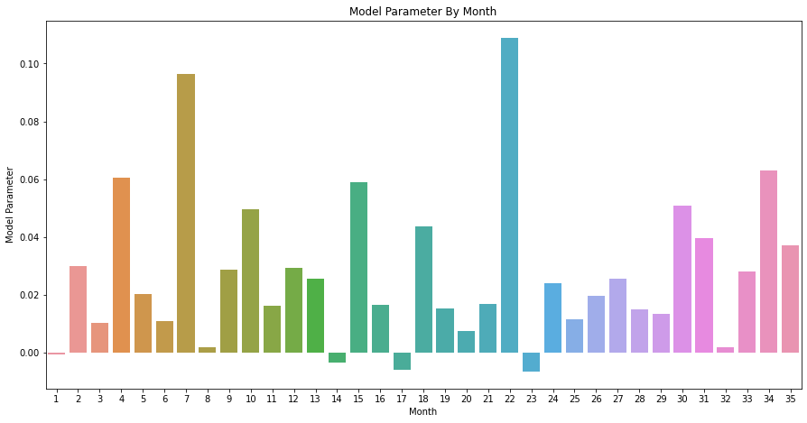

```python
model_parameters = optimal_model.coef_.flatten()
coefficients_df = pd.DataFrame(data={'Month': np.arange(1, 36), 'Coefficients': model_parameters})

plt.figure(figsize=(15, 7.5))
sns.barplot(data=coefficients_df, x='Month', y='Coefficients')
plt.xlabel('Month')
plt.ylabel('Model Parameter')
plt.title('Model Parameter By Month')
plt.show()
```

## Unfinished -- Ignore all below

Before we actually get started with the data wrangling/bootstrapping process, I think it is worth noting, again, that because we are training this model with data specifically from Huntington Hospital, we can really only say its predictions are valid for Huntington Hospital. That is not to say that its predictions aren't necessarily generalizable, but it take more rigorous testing to determine the extent to which this particular model will work for different clients.

```python
resampled = stripped_claims.query('Month == 1').sample(frac=1, replace=True, axis=0)
resampled
```

|  | Month | Year | Renewal Year | Domestic Medical Claims | Non-Domestic Medical Claims | Total Hospital Medical Claims | Non-Hospital Medical Claims | Total Medical Claims | Rx Claims | Rx Rebates | Rx Performance Guarantee | Stop Loss Reimbursement | Adjusted Paid Claims | Member Count | EE Count | PEPM |
| --- | --- | --- | --- | --- | --- | --- | --- | --- | --- | --- | --- | --- | --- | --- | --- | --- |
| 12 | 1 | 2016 | 1 | 469762.84 | 336373.14 | 806135.98 | 356117.04 | 1162253.02 | 449875.53 | 0.0 | 0.0 | 0.0 | 1612128.55 | 6256 | 2781 | 579.693833 |
| 0 | 1 | 2015 | 0 | 414313.73 | 324468.71 | 738782.44 | 385900.53 | 1124682.97 | 397849.95 | 0.0 | 0.0 | 0.0 | 1522532.92 | 6146 | 2690 | 565.997368 |
| 24 | 1 | 2017 | 2 | 420330.71 | 275861.09 | 696191.80 | 567471.93 | 1263663.73 | 451547.90 | 0.0 | 0.0 | 0.0 | 2527327.46 | 6623 | 3020 | 587.191524 |
| 24 | 1 | 2017 | 2 | 420330.71 | 275861.09 | 696191.80 | 567471.93 | 1263663.73 | 451547.90 | 0.0 | 0.0 | 0.0 | 2527327.46 | 6623 | 3020 | 587.191524 |
| 48 | 1 | 2019 | 4 | 683149.70 | 333269.75 | 1016419.45 | 558604.05 | 1575023.50 | 698954.69 | 0.0 | 0.0 | 0.0 | 2273978.19 | 6749 | 3108 | 731.653214 |
| 72 | 1 | 2021 | 6 | 308035.79 | 466745.22 | 774781.01 | 732462.14 | 1507243.15 | 601341.58 | 0.0 | 0.0 | 0.0 | 2108584.73 | 6758 | 3174 | 664.330413 |
| 0 | 1 | 2015 | 0 | 414313.73 | 324468.71 | 738782.44 | 385900.53 | 1124682.97 | 397849.95 | 0.0 | 0.0 | 0.0 | 1522532.92 | 6146 | 2690 | 565.997368 |
| 72 | 1 | 2021 | 6 | 308035.79 | 466745.22 | 774781.01 | 732462.14 | 1507243.15 | 601341.58 | 0.0 | 0.0 | 0.0 | 2108584.73 | 6758 | 3174 | 664.330413 |

```python
# Bootstrapping time!
resampled_months = pd.DataFrame(columns=['Month',
                                         'Year',
                                         'Total Medical Claims',
                                         'Rx Claims',
                                         'Rx Rebates',
                                         'Rx Performance Guarantee',
                                         'Stop Loss Reimbursement',
                                         'Adjusted Paid Claims'])

for num in np.arange(1, 13):
    for i in np.arange(100):
        each_month = stripped_claims.query('Month == @num').loc[:, 'Year':'Stop Loss Reimbursement']
        month = [num, num, num, num, num, num, num, num]
        year = [2015, 2016, 2017, 2018, 2019, 2020, 2021, 2022]
        df = {'Month': month, 'Year': year}
        resampled = pd.DataFrame(data=df)
        for column in each_month.columns[2:]:
            resample = each_month.loc[:, 'Year':column].sample(frac=1, replace=True, axis=0).reset_index().drop('index', axis=1)
            resampled[column] = resample[column]
        #claims_paid = resampled['Total Medical Claims'] \
        #            + resampled['Rx Claims']
        #reimbursements = resampled['Rx Rebates'] \
        #               + resampled['Rx Performance Guarantee'] \
        #               + resampled['Stop Loss Reimbursement']
        #resampled['Adjusted Paid Claims'] = claims_paid - reimbursements
        resampled_months = resampled_months.append(resampled)
resampled_months = resampled_months.reset_index().drop('index', axis=1).dropna()

# Further data transformations
def add_renewal_year(month, year):
    '''
    Function that returns a list of the corresponding Renewal Year for Huntington Medical Group
    -----
    Inputs:

    month (Python list) - Month column in resampled_months DataFrame

    year (Python list) - Year column in resampled_months DataFrame
    -----
    Output:

    renewal_year (Python list) - Corresponding renewal year column to be added to the
                                 resampled_months DataFrame
    '''
    renewal_year = []
    for i in np.arange(0, len(month)):
        if month[i] <= 5 and year[i] == 2015:
            renewal_year.append(0)
        elif month[i] >= 6 and year[i] == 2015:
            renewal_year.append(1)
        elif month[i] <=5 and year[i] == 2016:
            renewal_year.append(1)
        elif month[i] >= 6 and year[i] == 2016:
            renewal_year.append(2)
        elif month[i] <= 5 and year[i] == 2017:
            renewal_year.append(2)
        elif month[i] >= 6 and year[i] == 2017:
            renewal_year.append(3)
        elif month[i] <= 5 and year[i] == 2018:
            renewal_year.append(3)
        elif month[i] >= 6 and year[i] == 2018:
            renewal_year.append(4)
        elif month[i] <= 5 and year[i] == 2019:
            renewal_year.append(4)
        elif month[i] >= 6 and year[i] == 2019:
            renewal_year.append(5)
        elif month[i] <= 5 and year[i] == 2020:
            renewal_year.append(5)
        elif month[i] >= 6 and year[i] == 2020:
            renewal_year.append(6)
        elif month[i] <= 5 and year[i] == 2021:
            renewal_year.append(6)
        elif month[i] >= 6 and year[i] == 2021:
            renewal_year.append(7)
        elif month[i] <= 5 and year[i] == 2022:
            renewal_year.append(7)
        else:
            renewal_year.append(10)
    return renewal_year
resampled_months['Renewal Year'] = add_renewal_year(resampled_months['Month'].values, \
                                                    resampled_months['Year'].values)
resampled_months
```

|  | Month | Year | Total Medical Claims | Rx Claims | Rx Rebates | Rx Performance Guarantee | Stop Loss Reimbursement | Adjusted Paid Claims | Domestic Medical Claims | Non-Domestic Medical Claims | Total Hospital Medical Claims | Non-Hospital Medical Claims | Renewal Year |
| --- | --- | --- | --- | --- | --- | --- | --- | --- | --- | --- | --- | --- | --- |

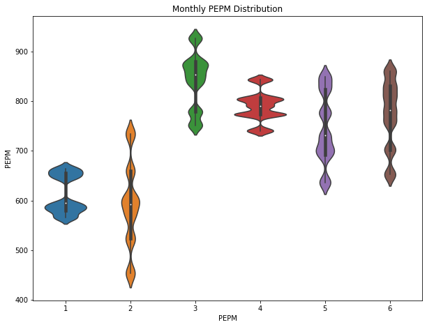

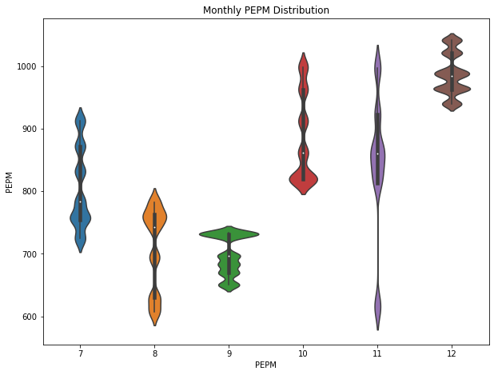

```python
# Violin plots for January-June
plt.figure(figsize=(10, 7.5))
sns.violinplot(data=resampled_months.query('Month <= 6'), x='Month', y='PEPM')
plt.xlabel('PEPM')
plt.title('Monthly PEPM Distribution')
plt.show()

# Violin plots for July-December
plt.figure(figsize=(10, 7.5))
sns.violinplot(data=resampled_months.query('Month > 6'), x='Month', y='PEPM')
plt.xlabel('PEPM')
plt.title('Monthly PEPM Distribution')
plt.show()
```

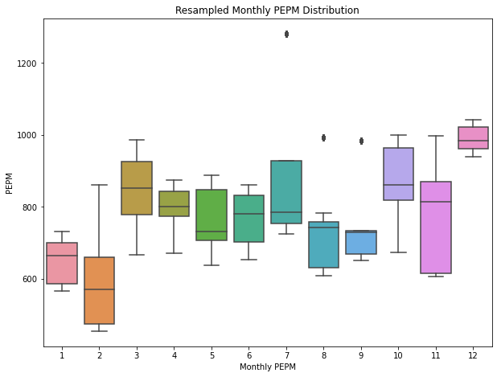

```python
# Boxplot version of the above
plt.figure(figsize=(10, 7.5))
sns.boxplot(data=resampled_months, x='Month', y='PEPM')
plt.xlabel('Monthly PEPM')
plt.title('Resampled Monthly PEPM Distribution')
plt.show()
```

```python
np.split(resampled_months.sort_values(['Month', 'Year', 'Renewal Year'], ascending=True).query('`Renewal Year` == 1')['PEPM'].values, 12)[0]
```

```
array([655.3354636, 655.3354636, 655.3354636, 579.6938332, 664.3304127,
       565.997368 , 646.3405145, 646.3405145, 646.3405145, 646.3405145,
       565.997368 , 664.3304127, 565.997368 , 699.2933386, 579.6938332,
       655.3354636, 646.3405145, 579.6938332, 594.6892155, 587.1915244,
       587.1915244, 579.6938332, 664.3304127, 664.3304127, 579.6938332,
       579.6938332, 664.3304127, 587.1915244, 565.997368 , 579.6938332,
       594.6892155, 587.1915244, 587.1915244, 646.3405145, 664.3304127,
       565.997368 , 655.3354636, 594.6892155, 655.3354636, 699.2933386,
       587.1915244, 594.6892155, 699.2933386, 594.6892155, 594.6892155,
       579.6938332, 579.6938332, 699.2933386, 587.1915244, 655.3354636,
       587.1915244, 664.3304127, 587.1915244, 664.3304127, 565.997368 ,
       579.6938332, 699.2933386, 594.6892155, 655.3354636, 594.6892155,
       594.6892155, 579.6938332, 594.6892155, 579.6938332, 699.2933386,
       664.3304127, 579.6938332, 587.1915244, 699.2933386, 655.3354636,
       587.1915244, 594.6892155, 664.3304127, 699.2933386, 594.6892155,
       587.1915244, 579.6938332, 664.3304127, 594.6892155, 699.2933386,
       565.997368 , 565.997368 , 594.6892155, 646.3405145, 565.997368 ,
       565.997368 , 646.3405145, 587.1915244, 594.6892155, 587.1915244,
       565.997368 , 664.3304127, 699.2933386, 699.2933386, 699.2933386,
       646.3405145, 664.3304127, 579.6938332, 579.6938332, 664.3304127])
```

```python
resampled_months.query('`Renewal Year` == 4')
```

|  | Month | Year | EE Count | PEPM | Renewal Year |
| --- | --- | --- | --- | --- | --- |
| 2003 | 6 | 2018 | 3210.0 | 808.097704 | 4 |
| 2007 | 6 | 2018 | 3095.0 | 757.194834 | 4 |
| 2011 | 6 | 2018 | 3167.0 | 831.153148 | 4 |
| 2015 | 6 | 2018 | 3210.0 | 808.097704 | 4 |
| 2019 | 6 | 2018 | 2675.0 | 652.563948 | 4 |
| ... | ... | ... | ... | ... | ... |
| 4783 | 12 | 2018 | 3055.0 | 962.650276 | 4 |
| 4787 | 12 | 2018 | 3116.0 | 966.030113 | 4 |
| 4791 | 12 | 2018 | 3001.0 | 991.919943 | 4 |
| 4795 | 12 | 2018 | 3055.0 | 962.650276 | 4 |
| 4799 | 12 | 2018 | 3055.0 | 962.650276 | 4 |

700 rows × 5 columns

[output not shown]

Now that we have a bootstrapped dataset, let's look at it and see if it seems to have successfully rebuilt the population.

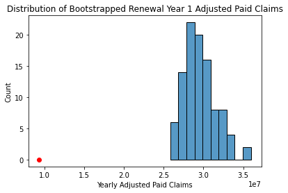

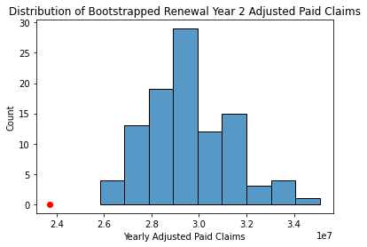

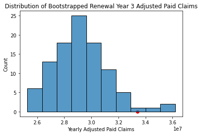

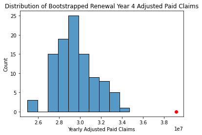

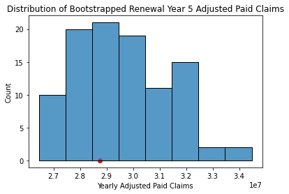

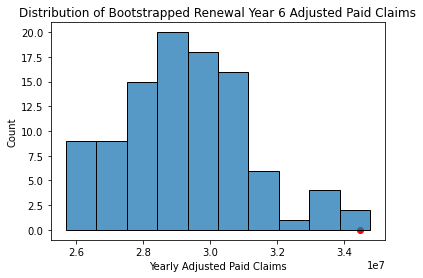

```python
apcs = [apc_ryr1, apc_ryr2, apc_ryr3, apc_ryr4, apc_ryr5, apc_ryr6]
observed_yearly_apcs = claims.groupby('Renewal Year').sum()['Adjusted Paid Claims'].values
i = 0
for apc in apcs:
    observed_year_apc = observed_yearly_apcs[i]
    sns.histplot(data=apc)
    plt.xlabel('Yearly Adjusted Paid Claims')
    plt.title(f'Distribution of Bootstrapped Renewal Year {i + 1} Adjusted Paid Claims')
    plt.scatter(observed_year_apc, -0.01, color='red')
    plt.show()
    i += 1
```

[figure not shown]

```python
sns.histplot()
```

```python
def strip_month_year(month_number, year):
    '''
    Strips Adjusted Paid Claims values for a given month_number and year from resampled_months
    and returns a NumPy array
    -----
    Inputs:

    month_number (int) - Integer corresponding to the month desired

    year (int) - Integer corresponding to the year desired
    -----
    Output:

    month_year (NumPy Array) - Adjusted Paid Claims values from resampled_months corresponding to
                               the month and year specified
    '''
    return resampled_months.query('Month == @month_number and Year == @year')['Adjusted Paid Claims'].values

jan_2015, feb_2015, mar_2015 = [strip_month_year(month_num, 2015) for month_num in np.arange(1, 4)]
apr_2015, may_2015, jun_2015 = [strip_month_year(month_num, 2015) for month_num in np.arange(4, 7)]
jul_2015, aug_2015, sep_2015 = [strip_month_year(month_num, 2015) for month_num in np.arange(7, 10)]
oct_2015, nov_2015, dec_2015 = [strip_month_year(month_num, 2015) for month_num in np.arange(10, 13)]

jan_2016, feb_2016, mar_2016 = [strip_month_year(month_num, 2016) for month_num in np.arange(1, 4)]
apr_2016, may_2016, jun_2016 = [strip_month_year(month_num, 2016) for month_num in np.arange(4, 7)]
jul_2016, aug_2016, sep_2016 = [strip_month_year(month_num, 2016) for month_num in np.arange(7, 10)]
oct_2016, nov_2016, dec_2016 = [strip_month_year(month_num, 2016) for month_num in np.arange(10, 13)]

jan_2017, feb_2017, mar_2017 = [strip_month_year(month_num, 2017) for month_num in np.arange(1, 4)]
apr_2017, may_2017, jun_2017 = [strip_month_year(month_num, 2017) for month_num in np.arange(4, 7)]
jul_2017, aug_2017, sep_2017 = [strip_month_year(month_num, 2017) for month_num in np.arange(7, 10)]
oct_2017, nov_2017, dec_2017 = [strip_month_year(month_num, 2017) for month_num in np.arange(10, 13)]

jan_2018, feb_2018, mar_2018 = [strip_month_year(month_num, 2018) for month_num in np.arange(1, 4)]
apr_2018, may_2018, jun_2018 = [strip_month_year(month_num, 2018) for month_num in np.arange(4, 7)]
jul_2018, aug_2018, sep_2018 = [strip_month_year(month_num, 2018) for month_num in np.arange(7, 10)]
oct_2018, nov_2018, dec_2018 = [strip_month_year(month_num, 2018) for month_num in np.arange(10, 13)]

jan_2019, feb_2019, mar_2019 = [strip_month_year(month_num, 2019) for month_num in np.arange(1, 4)]
apr_2019, may_2019, jun_2019 = [strip_month_year(month_num, 2019) for month_num in np.arange(4, 7)]
jul_2019, aug_2019, sep_2019 = [strip_month_year(month_num, 2019) for month_num in np.arange(7, 10)]
oct_2019, nov_2019, dec_2019 = [strip_month_year(month_num, 2019) for month_num in np.arange(10, 13)]

jan_2020, feb_2020, mar_2020 = [strip_month_year(month_num, 2020) for month_num in np.arange(1, 4)]
apr_2020, may_2020, jun_2020 = [strip_month_year(month_num, 2020) for month_num in np.arange(4, 7)]
jul_2020, aug_2020, sep_2020 = [strip_month_year(month_num, 2020) for month_num in np.arange(7, 10)]
oct_2020, nov_2020, dec_2020 = [strip_month_year(month_num, 2020) for month_num in np.arange(10, 13)]

jan_2021, feb_2021, mar_2021 = [strip_month_year(month_num, 2021) for month_num in np.arange(1, 4)]
apr_2021, may_2021, jun_2021 = [strip_month_year(month_num, 2021) for month_num in np.arange(4, 7)]
jul_2021, aug_2021, sep_2021 = [strip_month_year(month_num, 2021) for month_num in np.arange(7, 10)]
oct_2021, nov_2021, dec_2021 = [strip_month_year(month_num, 2021) for month_num in np.arange(10, 13)]
```

```python
def aggregate_renewal_year(renewal_year):
    '''
    For the specified renewal_year, calculates the Total Adjusted Paid Claims values for
    the 100 resamples
    -----
    Input:

    renewal_year (int) - The specified renewal year (starting with 1 from 6/15-5/16)
    -----
    Outputs:

    renewal_year_totals (NumPy Array) - The Adjusted Paid Values for the 100 resamples
                                        corresponding to the specified renewal_year

    renewal_label (NumPy Array) - NumPy Array consisting of the Renewal Year for inputting
                                  into a DataFrame
    '''
    renewal_label = np.zeros(0)
    if renewal_year == 1:
        renewal_year_totals = jun_2015 + jul_2015 + aug_2015 + sep_2015 + \
                              oct_2015 + nov_2015 + dec_2015 + jan_2016 + \
                              feb_2016 + mar_2016 + apr_2016 + may_2016
    elif renewal_year == 2:
        renewal_year_totals = jun_2016 + jul_2016 + aug_2016 + sep_2016 + \
                              oct_2016 + nov_2016 + dec_2016 + jan_2017 + \
                              feb_2017 + mar_2017 + apr_2017 + may_2017
    elif renewal_year == 3:
        renewal_year_totals = jun_2017 + jul_2017 + aug_2017 + sep_2017 + \
                              oct_2017 + nov_2017 + dec_2017 + jan_2018 + \
                              feb_2018 + mar_2018 + apr_2018 + may_2018
    elif renewal_year == 4:
        renewal_year_totals = jun_2018 + jul_2018 + aug_2018 + sep_2018 + \
                              oct_2018 + nov_2018 + dec_2018 + jan_2019 + \
                              feb_2019 + mar_2019 + apr_2019 + may_2019
    elif renewal_year == 5:
        renewal_year_totals = jun_2019 + jul_2019 + aug_2019 + sep_2019 + \
                              oct_2019 + nov_2019 + dec_2019 + jan_2020 + \
                              feb_2020 + mar_2020 + apr_2020 + may_2020
    elif renewal_year == 6:
        renewal_year_totals = jun_2020 + jul_2020 + aug_2020 + sep_2020 + \
                              oct_2020 + nov_2020 + dec_2020 + jan_2021 + \
                              feb_2021 + mar_2021 + apr_2021 + may_2021
    for i in range(len(renewal_year_totals)):
        renewal_label = np.append(renewal_label, int(renewal_year))
    return renewal_year_totals, renewal_label
```

[output not shown]

```python
resampled_months['Year'].value_counts()
```

```
2020    1200
2019    1200
2018    1200
2017    1200
2016    1200
2015    1200
2021     400
Name: Year, dtype: int64
```

```python
resampled_months['Month'].value_counts()
```

```
4     700
3     700
2     700
1     700
12    600
11    600
10    600
9     600
8     600
7     600
6     600
5     600
Name: Month, dtype: int64
```